# Final_report

Gangaprasad Shahapurkar

April 4, 2019

## Introduction

In this final report we are supposed to apply the learnings from the course on one of the datasets provided.

```r
#library(readr) #read files from disk
library(tidyverse) #data manipulation
library(cluster) #clustering algorithms
```

## Step 1 - Dataset selection

The dataset that i will be working on as part of this report will be **Bike Vendors**. Reading the data below in a dataframe named **df** and check the column names

```r
df <- read_csv("../Data/bikeVendors.csv") # Read the data
dim(df) #print dimension details
```

```
## [1] 97 35
```

```r
names(df) #Display column names
```

```
##  [1] "model"                        "category1"
##  [3] "category2"                    "frame"
##  [5] "price"                        "Albuquerque Cycles"
##  [7] "Ann Arbor Speed"              "Austin Cruisers"
##  [9] "Cincinnati Speed"             "Columbus Race Equipment"
## [11] "Dallas Cycles"                "Denver Bike Shop"
## [13] "Detroit Cycles"               "Indianapolis Velocipedes"
## [15] "Ithaca Mountain Climbers"     "Kansas City 29ers"
## [17] "Las Vegas Cycles"             "Los Angeles Cycles"
## [19] "Louisville Race Equipment"    "Miami Race Equipment"
## [21] "Minneapolis Bike Shop"        "Nashville Cruisers"
## [23] "New Orleans Velocipedes"      "New York Cycles"
## [25] "Oklahoma City Race Equipment" "Philadelphia Bike Shop"
## [27] "Phoenix Bi-peds"              "Pittsburgh Mountain Machines"
## [29] "Portland Bi-peds"             "Providence Bi-peds"
## [31] "San Antonio Bike Shop"        "San Francisco Cruisers"
## [33] "Seattle Race Equipment"       "Tampa 29ers"
## [35] "Wichita Speed"
```

There seems to be extra space in the column names, so let us remove those extra spaces.

```r
names(df) <- make.names(names(df)) # Removing extra column spaces
```

## Step 2 - Epicycle analysis of data

We will be applying all 5 core activities of epicycle analysis of data as part of the final report. Below are 5 core activities that are performed as part of data analaysis.

1. Stating and refining the question
2. Exploring the data
3. Building formal statistical models
4. Interpreting the results
5. Communicating the results

Let us take step by step approach to work on the dataset choosen. Begining with step 1, let us set the expectation about the data

## Step 3 - Data Description

The selected dataset **Bike Vendors** has **97** observations and **35** variables. It is seen that out of 35 variables **4** variables are of type **char** and remaining variables are **numeric**

Below are the column names of the dataset after removing the extra spaces.

```
##  [1] "model"                        "category1"
##  [3] "category2"                    "frame"
##  [5] "price"                        "Albuquerque.Cycles"
##  [7] "Ann.Arbor.Speed"              "Austin.Cruisers"
##  [9] "Cincinnati.Speed"             "Columbus.Race.Equipment"
## [11] "Dallas.Cycles"                "Denver.Bike.Shop"
## [13] "Detroit.Cycles"               "Indianapolis.Velocipedes"
## [15] "Ithaca.Mountain.Climbers"     "Kansas.City.29ers"
## [17] "Las.Vegas.Cycles"             "Los.Angeles.Cycles"
## [19] "Louisville.Race.Equipment"    "Miami.Race.Equipment"
## [21] "Minneapolis.Bike.Shop"        "Nashville.Cruisers"
## [23] "New.Orleans.Velocipedes"      "New.York.Cycles"
## [25] "Oklahoma.City.Race.Equipment" "Philadelphia.Bike.Shop"
## [27] "Phoenix.Bi.peds"              "Pittsburgh.Mountain.Machines"
## [29] "Portland.Bi.peds"             "Providence.Bi.peds"
## [31] "San.Antonio.Bike.Shop"        "San.Francisco.Cruisers"
## [33] "Seattle.Race.Equipment"       "Tampa.29ers"
## [35] "Wichita.Speed"
```

The first 5 variables in the dataset **“model”, “category1”, “category2”, “frame”, “price”** define model, type of bike and their sale price. The remaining 30 variables are vendors of these bikes and observations listed are the price distribution for these models.

Based on the data we can find answers to some of the below questions

1. Which category has more bike options?
2. Which are Top 5 costlier bikes and Top 5 cheaper bikes ?
3. What is mean price of bikes for each frame type?

## Step 4 - Data Exploration

### Exploratory plots and descriptions

As we noticed, this dataset has categorization of bikes, their price and price distribution at different vendors. Let us explore the data based on different factors. There are 2 broad categories of bikes based on type of frame. As we can see that there more number of models available for frame type carbon than Aluminum

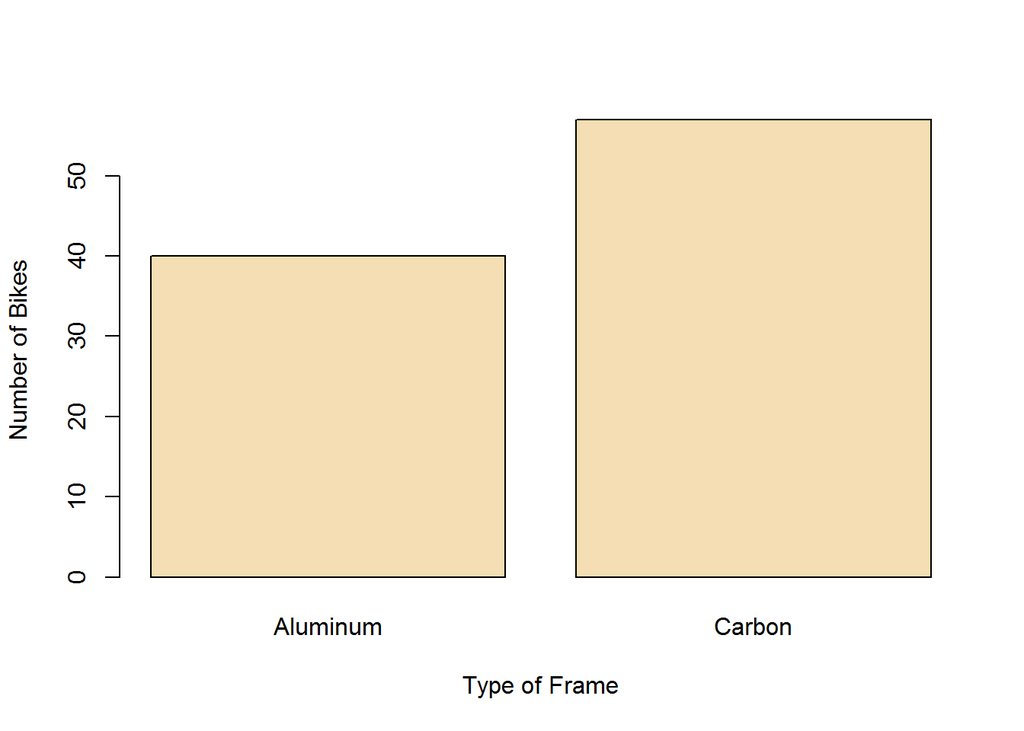

```r
table(df$frame) %>% barplot(col="wheat", xlab = "Type of Frame", ylab = "Number of Bikes")
```

**Average bike price based on frame type**

```
## # A tibble: 2 x 2
##   frame    `mean(price)`
##   <chr>            <dbl>
## 1 Aluminum         1980.
## 2 Carbon           5339.
```

There are also 2 more factors based on which bikes are categorized. It is category1 and Category2. Below is the summary of bike based on those two category.

```
## # A tibble: 13 x 4
##    frame    category1 category2              n
##    <chr>    <chr>     <chr>              <int>
##  1 Aluminum Mountain  Cross Country Race     5
##  2 Aluminum Mountain  Fat Bike               2
##  3 Aluminum Mountain  Sport                  9
##  4 Aluminum Mountain  Trail                  8
##  5 Aluminum Road      Elite Road            11
##  6 Aluminum Road      Endurance Road         5
##  7 Carbon   Mountain  Cross Country Race    14
##  8 Carbon   Mountain  Over Mountain          8
##  9 Carbon   Mountain  Trail                  5
## 10 Carbon   Road      Cyclocross             4
## 11 Carbon   Road      Elite Road            10
## 12 Carbon   Road      Endurance Road        11
## 13 Carbon   Road      Triathalon             5
```

There is largest collection of bikes available in **Cross Country Race** category which are **Carbon** frame based **Mountain bikes**. We can also see that there are only 2 bike option available in **Fat Bike** category which **Aluminum** frame based **Mountain bikes**

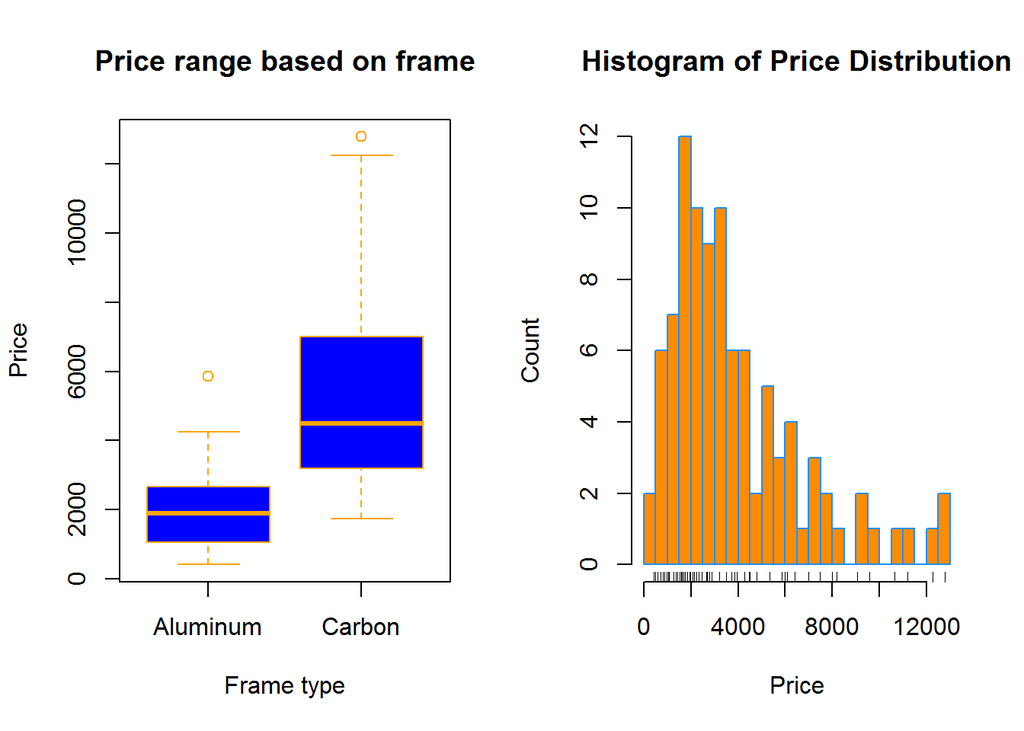

```r
par(mfrow = c(1,2))
boxplot(df$price~df$frame, main="Price range based on frame", xlab="Frame type", ylab = "Price", col="blue", border = "orange")

hist(df$price, col="darkorange", border="dodgerblue", breaks = 30, main = "Histogram of Price Distribution", xlab = "Price", ylab = "Count")
rug(df$price)
```

If we see the overall distribution of the price we can notice that more number of bike options are available in price range say 1500 to 4000.

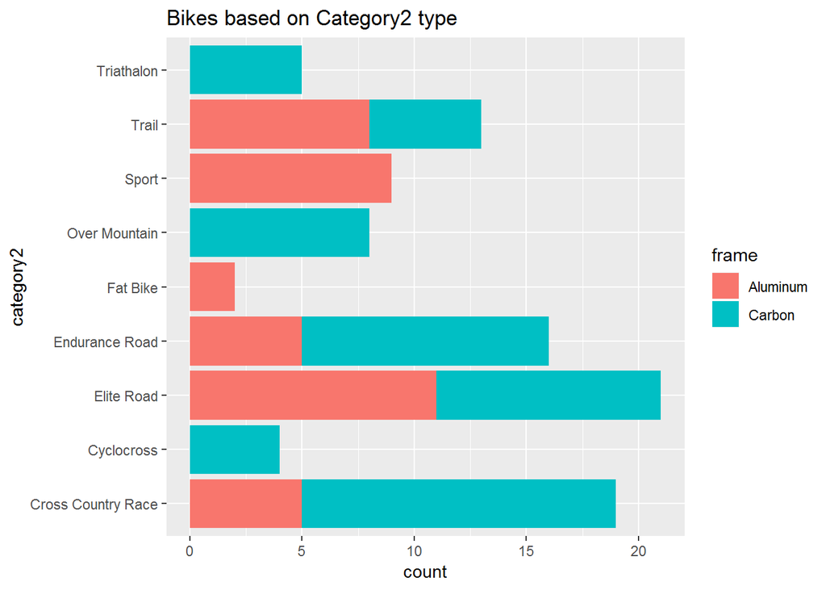

```r
g_bike <- ggplot(df, aes(category2, fill = frame))
g_bike + geom_bar(position = position_stack(reverse = TRUE)) + ggtitle("Bikes based on Category2 type") + coord_flip()
```

### Cluster analysis

For Cluster analysis we would require all numerical data. I have selected **San.Francisco.Cruisers**, **Seattle.Race.Equipment**, and **Tampa.29ers** columns for clustering. Below are the details of the subset of the data selected for clustering.

```r
df_cluster <- df[,32:34] #extract the columns for clustering
dim(df_cluster) #print dimension of cluster
```

```
## [1] 97  3
```

Using the kmeans() internal function of R i have defined cluster of size 3. Since i have selected data for 3 different venders i have selected number of cluster as 3.

```r
#Apply k-means cluster
clus_output <- kmeans(df_cluster,3)
clus_output
```

```
## K-means clustering with 3 clusters of sizes 45, 21, 31
##
## Cluster means:
##   San.Francisco.Cruisers Seattle.Race.Equipment Tampa.29ers
## 1            0.006298277            0.004166667 0.006040993
## 2            0.009294627            0.006324405 0.029357374
## 3            0.016819044            0.021925403 0.003601629
##
## Clustering vector:
##  [1] 2 1 1 2 1 1 3 1 3 2 3 1 1 3 1 3 1 1 1 2 1 1 1 2 1 1 1 1 2 1 1 3 3 1 2
## [36] 1 1 1 1 2 1 2 2 2 1 2 1 2 1 1 2 2 2 3 3 3 3 3 1 3 1 2 1 1 1 3 3 1 1 2
## [71] 1 3 1 3 3 3 3 3 3 3 3 3 3 1 3 3 3 3 1 1 1 1 2 1 2 3 2
##
## Within cluster sum of squares by cluster:
## [1] 0.004568501 0.003750814 0.007323501
##  (between_SS / total_SS =  53.7 %)
##
## Available components:
##
## [1] "cluster"      "centers"      "totss"        "withinss"
## [5] "tot.withinss" "betweenss"    "size"         "iter"
## [9] "ifault"
```

As we can see, after applying k-means clustering, the output has 3 clusters with size 31, 45, 21. The results also present cluster means. The clustering vector shows how each of these 97 data points is categorized into three clusters. The within cluster sum of squares are also presented. The within cluster sum of squares measure the variability of the points within each cluster. The data points in a cluster with a larger value of within cluster sum of square have greater variability. But such square varies by the number of data points in one cluster.

The k-means results also provide many components we could view. For example, If we want to know the size of each cluster, we could do it by the following command

```r
clus_output$size
```

```
## [1] 45 21 31
```

```r
clus_output$cluster
```

```
##  [1] 2 1 1 2 1 1 3 1 3 2 3 1 1 3 1 3 1 1 1 2 1 1 1 2 1 1 1 1 2 1 1 3 3 1 2
## [36] 1 1 1 1 2 1 2 2 2 1 2 1 2 1 1 2 2 2 3 3 3 3 3 1 3 1 2 1 1 1 3 3 1 1 2
## [71] 1 3 1 3 3 3 3 3 3 3 3 3 3 1 3 3 3 3 1 1 1 1 2 1 2 3 2
```

In order to check how good this fit has been we would plot the dataset. The data points will be coloured by clustering results

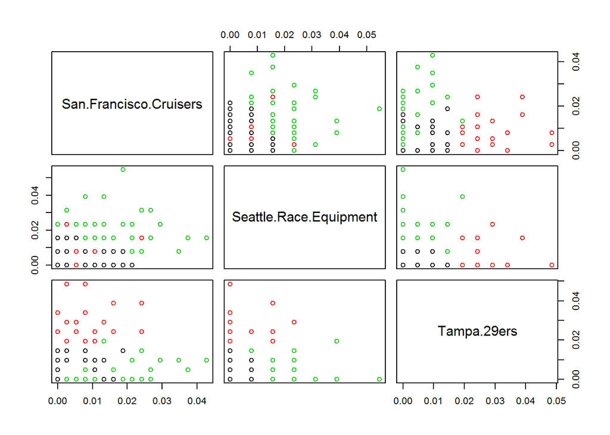

```r
#Plot the clusters with different color as the model
plot(df_cluster, col=clus_output$cluster)
```

We can see that the three clusters are reflected by points in black, green, and red. When we plot the clusters, we could see that these clusters are clearly separated by the combination of some attributes, such as **San.Francisco.Cruisers**, **Seattle.Race.Equipment**, and **Tampa.29ers**. It is also obvious that the clusters have different sizes.

Now we want to compare the fit of clusters by our model and the original clusters by the attribute price.

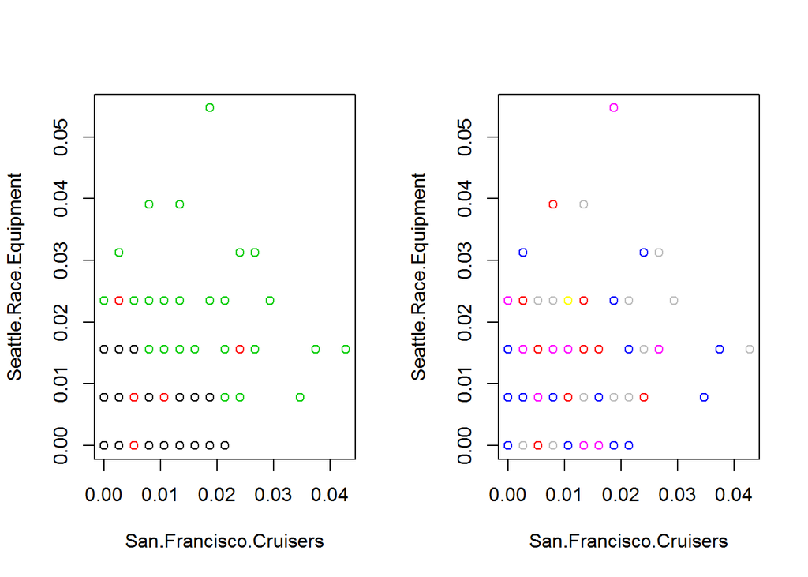

```r
par(mfrow = c(1,2))
plot(df[c("San.Francisco.Cruisers","Seattle.Race.Equipment")], col=clus_output$cluster)
plot(df[c("San.Francisco.Cruisers","Seattle.Race.Equipment")], col=df$price)
```

Below output shows how the prices are clustered

```r
table(df$price,clus_output$cluster)
##
##         1 2 3
##   415   0 1 0
##   480   1 0 0
##   585   1 0 0
##   705   1 0 0
##   815   0 1 1
##   870   0 0 1
##   980   1 0 0
##   1030  1 0 1
##   1080  1 0 0
##   1250  0 0 2
##   1350  1 0 0
##   1410  1 0 0
##   1520  1 0 0
##   1570  0 0 1
##   1620  1 0 0
##   1680  0 0 1
##   1750  1 0 0
##   1840  2 0 1
##   1950  0 0 3
##   1960  1 0 0
##   2060  1 0 0
##   2130  1 1 1
##   2240  2 0 1
##   2340  1 0 1
##   2450  0 0 1
##   2660  3 0 2
##   2700  0 0 1
##   2770  1 0 0
##   2880  2 0 0
##   3200  1 4 4
##   3500  0 1 0
##   3730  1 1 2
##   3840  1 0 0
##   3940  1 0 0
##   4260  2 2 0
##   4480  1 0 0
##   4500  0 0 1
##   4800  1 0 1
##   5330  0 4 1
##   5860  1 0 1
##   5970  0 1 0
##   6070  0 1 0
##   6390  2 1 0
##   7000  0 0 1
##   7460  1 1 1
##   7990  2 0 0
##   8200  1 0 0
##   9060  2 0 0
##   9590  1 0 0
##   10660 1 0 0
##   11190 0 1 0
##   12250 1 0 0
##   12790 0 1 1
```

### Regression analysis

For performing regression analysis on the data we would need to choose one dependent variable and one independent variable.For the below dataset i am considering price as my dependent variable and the vendor data as independent variable. To validate this we need to make a Null hypothesis that there is no linear relation. I am making plot between **price** and 3 other vendors i.e. **San.Francisco.Cruisers**, **Seattle.Race.Equipment**, and **Tampa.29ers**. We need to calculate mean of **price** and plot horizontal line which is equal to mean value.This is our null hypothesis that will be shown by using abline() function.

```r
df1 <- df #create copy of dataset
df1 <- mutate_at(df1, vars(model,category1, category2,frame), as.factor) #Factor character data

#Null Hypothesis
#Calculate mean concentration
mean.df1 = mean(df1$price)
mean.df1
```

```
## [1] 3953.763
```

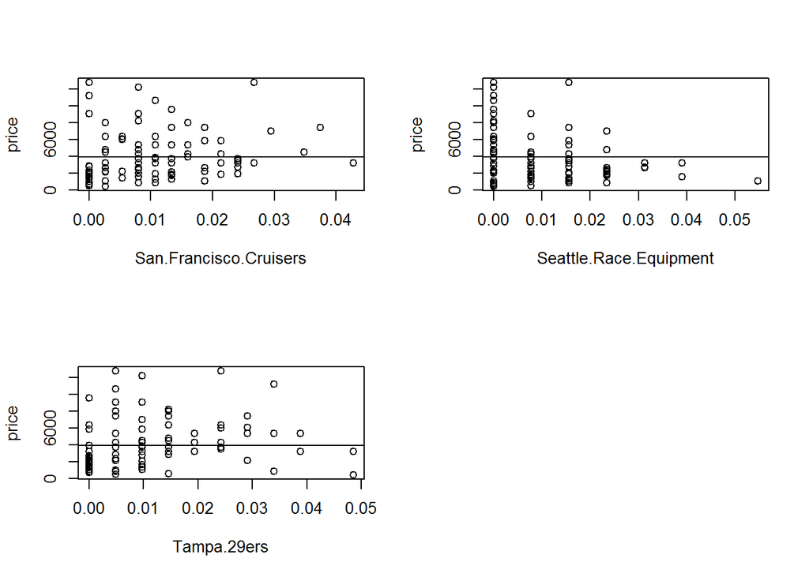

```r
par(mfrow = c(2,2))
plot(price~San.Francisco.Cruisers, data=df1)
abline(h=mean.df1) #Plot horizontal line

plot(price~Seattle.Race.Equipment, data=df1)
abline(h=mean.df1)

plot(price~Tampa.29ers, data=df1)
abline(h=mean.df1)
```

Below is my linear regression model by using *lm* package

```r
#lm model to fit a regression line through the data
lmodel <- lm(price~San.Francisco.Cruisers+Seattle.Race.Equipment+Tampa.29ers, data=df1)
summary(lmodel)
```

```
##
## Call:
## lm(formula = price ~ San.Francisco.Cruisers + Seattle.Race.Equipment +
##     Tampa.29ers, data = df1)
##
## Residuals:
##     Min      1Q  Median      3Q     Max
## -5173.4 -1659.3  -512.2   973.1  8255.1
##
## Coefficients:
##                        Estimate Std. Error t value Pr(>|t|)
## (Intercept)              3714.4      530.2   7.006 3.81e-10 ***
## San.Francisco.Cruisers  87110.3    29604.1   2.943 0.004110 **
## Seattle.Race.Equipment -97694.3    26214.5  -3.727 0.000333 ***
## Tampa.29ers             33806.8    23244.4   1.454 0.149200
## ---
## Signif. codes:  0 '***' 0.001 '**' 0.01 '*' 0.05 '.' 0.1 ' ' 1
##
## Residual standard error: 2601 on 93 degrees of freedom
## Multiple R-squared:  0.2056, Adjusted R-squared:  0.1799
## F-statistic: 8.022 on 3 and 93 DF,  p-value: 8.23e-05
```

From the model output , we could see the coeffcients of regression line. In order to check how good our model will fit with data we need to plot the residuals and fitted model

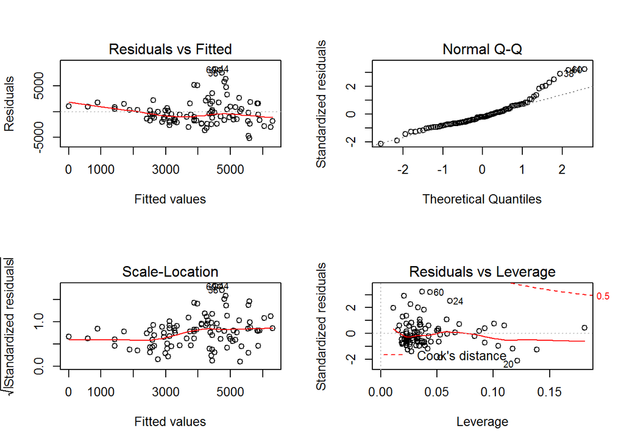

```r
#Calculate residuals
par(mfrow = c(2,2))
plot(lmodel)
```

By observing above plots, we can say that the linear model has fitted our data to some extent. From the Multiple R-Squared provided by summary() function above, we could see that **20.56%** of the data could be explained by the linear model.

## Results

Based on the overall analysis conducted on the **bikeVendors** dataset we got below insights.

```
## # A tibble: 5 x 3
##   model                    category2          price
##   <chr>                    <chr>              <dbl>
## 1 Scalpel-Si Black Inc.    Cross Country Race 12790
## 2 Supersix Evo Black Inc.  Elite Road         12790
## 3 Habit Hi-Mod Black Inc.  Trail              12250
## 4 F-Si Black Inc.          Cross Country Race 11190
## 5 Supersix Evo Hi-Mod Team Elite Road         10660
```

```
## # A tibble: 5 x 3
##   model        category2  price
##   <chr>        <chr>      <dbl>
## 1 Catalyst 4   Sport        415
## 2 Catalyst 3   Sport        480
## 3 Catalyst 2   Sport        585
## 4 Catalyst 1   Sport        705
## 5 CAAD8 Claris Elite Road   815
```

3. Average price for **Carbon** frame based bikes is 5339 and for **Aluminum** frame based bikes 1980

```
## # A tibble: 2 x 2
##   frame    `mean(price)`
##   <chr>            <dbl>
## 1 Aluminum         1980.
## 2 Carbon           5339.
```